# Logistic Regression for Thermostability

November 2023

## Summary of predictive models

|  | Log regression on pepfeatures | Neural net on pepfeatures | Graph neural net with proteinBERT |
| --- | --- | --- | --- |
| Test acc. | 95.7% | 96.7% | 96.9 |
| Train acc. | 99.7% | 97.6 | 97.3% |

- Neural net methods work best
- Logistic regression is close behind

## Prediction vs interpretation

Contrasting questions:-

1. Is a protein thermostable, given its sequence and structure?
2. Which structural elements contribute to thermostability? \[\\[1ex]\]

Statistics vs machine learning:-

1. Black-box / neural nets will win for **prediction accuracy** as quantity of data increases
2. Neural net approaches remain opaque; statistical / **model-based** approaches win for **interpretability**

## Logistic regression model

- \(x=\) feature vector for a protein
- \(p(x)=\) Pr(protein is thermostable) \[\\[1ex]\]

Logistic regression model:-

\[\frac{p(x)}{1-p(x)} = e^{\{\beta_0+\langle \beta,x \rangle\}}\] where \(\beta\) is a vector of coefficients, \(\langle \beta,x \rangle =\) vector inner product \[\\[1ex]\]

Model fitting:-

- Which coefficients are non-zero (significance)?
- Which coefficients are largest?

## Geometrical interpretation

- Coefficients \(\beta\) give a **direction vector** in feature space which best distinguishes between classes
- Could we change the feature space to a space of graphs?

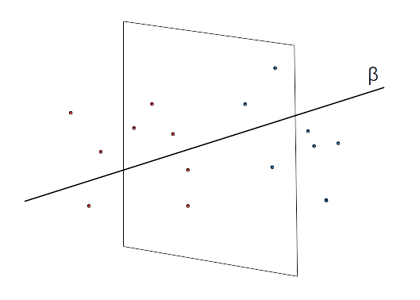

Red: stable; blue: unstable

## Directions in graph space

- A direction vector in a space of graphs is a continuous path or **animation** or graphs
- As you traverse the path you move from thermostable to unstable
- Next slide shows a path through a space of graphs (press the play button, bottom right)

Note:-

- Our visualisation would additionally include vertex and edge **atttributes** changing
- E.g. hydrophobicity at vertex shown as size or weight of vertex

## A path through graph space

[interactive chart not shown]

## Proposed methodology

- Represent protein as a **graph** – contact graph
- Assign **attributes** to edges and vertices
  - Numerical parameters characterising sequence and structure
  - Select parameters to maintain **interpretability**
- Develop logistic regression in graph space
  - Use existing graph space of [Callisano and Feragen](https://academic.oup.com/biomet/advance-article-abstract/doi/10.1093/biomet/asad024/7103300)
  - Contains basic ingredients for regression with graph-valued covariate \[\\[1ex]\]

Unresolved issues:-

- Best graph representation of a protein?
- Attribute selection?

## Possible funding mechanism

- Innovate UK – [Accelerated Knowledge Transfer](https://www.ktp-uk.org/accelerated-knowledge-transfer/#:~:text=Innovate%20UK%20%E2%80%93%20Accelerated%20Knowledge%20Transfer%20is%20designed%20to%20build%20an,the%20potential%20for%20significant%20impact)
- Grant size up to approx £35k
  - 4 months PhD / PDRA (Will)
  - 0.5 days a week academic (Tom)
- Industrial partner provides **10% funding** or more
- Application deadline **13 December** 2023
- Decisions made Feb 2024, project runs March 2024–July 2024